# R Open Labs

## Introduction

#### University of North Carolina at Chapel Hill

#### September 6, 2018

## What’s an Open Lab?

Open labs are (mostly) unstructured workshops designed to help you learn R. Each week brief instruction will be provided, followed by time to practice, work together, ask questions and get help. Participants can join the lab any time during the session, and are welcome to work on unrelated projects.

The Open Labs model was established by our colleagues at Columbia with excellent results, and now we’re giving it a try. Our goal is to connect researchers and foster a community for R users on campus.

## Why R?

R is widely used in statistics and has become quite popular in the biomedical and social sciences over the last decade. Essentially R can be used as either a programming language or as a standard statistical package that operates much like Stata, SAS, or SPSS.

R is open source and free to use for any purpose. This has clear advantages and a few disadvantages:

Advantages

- Free!
- Portable (Windows, macOS, Linux)
- [Flexible publication quality graphics](http://www.ggplot2-exts.org/gallery/)
- [Interactive visualization](https://shiny.rstudio.com/gallery/)
- [Reproducible reports](https://rmarkdown.rstudio.com/gallery.html)
- Active user base
  - Blogs, forums, StackOverflow, etc. provide many avenues of support
  - Many new methods (e.g. [lasso regression](https://web.stanford.edu/~hastie/glmnet/glmnet_alpha.html), [Bayesian multilevel modeling](https://cran.r-project.org/web/packages/brms/vignettes/brms_phylogenetics.html), and [deep learning](https://tensorflow.rstudio.com/learn/gallery.html)) quickly appear as R libraries

Disadvantages

- No commercial support
  - R is available free as is. If something doesn’t exist or doesn’t work the way you think it should you can wait for someone else to (hopefully) build it, or it’s up to you
  - No commercial hotline for help
  - Support and libraries from other users varies by popularity of method/area of study.

## Learning objectives for the semester

R is a big tent that supports a variety of programming styles and tasks, so we can’t possibly cover all of it. The brief instruction periods will focus on using R for analyzing data. If you are interested in software development in R, you can use the unstructured time for help with that. We’ll also provide links to some great online resources for software development in R.

Since the focus of these labs is using R for data analysis, we are going to focus on the [Tidyverse](https://www.tidyverse.org/). The authors of the Tidyverse have also written a free ebook, [R for Data Science](http://r4ds.had.co.nz/). We will not follow this book exactly, but for each of our workshops we will announce the corresponding chapters from the book, so you can have an additional perspective on what we are teaching.

This workshop **does not** aim to give a comprehensive introduction to R. We assume most attendees have at least some R experience.

If you don’t have any R experience, don’t worry! The Open Labs can still provide support and a community to help you learn, **but** you’ll need to work outside the Open Labs to learn some of the basics.

We also hope to empower you to become a self-sufficient R user, so we’ll be showing you examples of how to troubleshoot and debug R code.

## Today

This introductory workshop aims to:

- Install R and R Studio if you haven’t already
- Briefly familiarize or re-familiarize you with some of the most important elements of R
  - RStudio interface
  - Tidyverse library
  - Graphics using ggplot2
  - Data types
- [R for Data Science Chapters 1-3](http://r4ds.had.co.nz/introduction.html)

## Install R and R Studio

1. Download R at https://cran.r-project.org/
2. If possible, install the additional R developer tools. This can help in the future because some libraries require these. If your computer is not updated to the latest version of your operating system, this can get a little hairy, so don’t worry if you can’t get this done today.
- For Windows: https://cran.r-project.org/bin/windows/Rtools/
- For macOS: https://cran.r-project.org/bin/macosx/tools/
3. Download R Studio at https://www.rstudio.com/products/rstudio/download/#download

## R Studio interface

[figure not shown]

## Panes

R Studio shows four panes by default. The two most important for writing, testing, and executing R code are the console and the script editor.

### Console (bottom left)

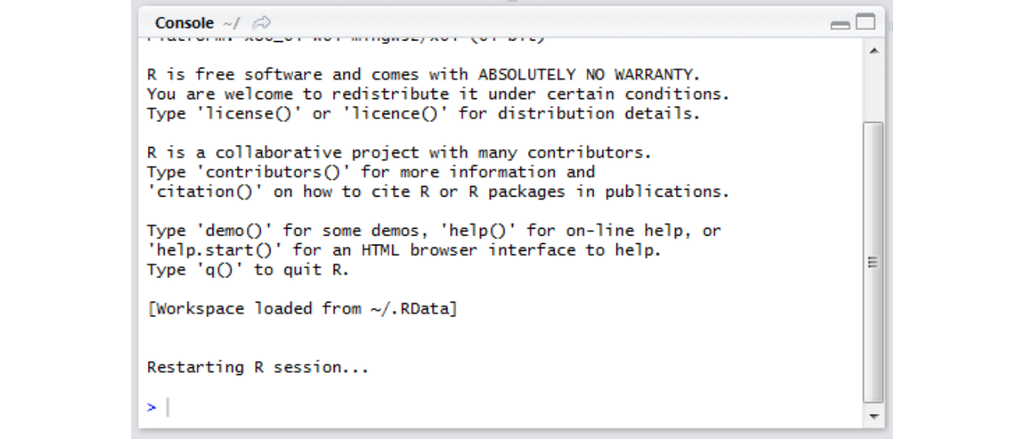

The console pane allows immediate execution of R code. This pane can be used to experiment with new functions and execute one-off commands, like printing sample data or exploratory plots.

Type next to the `>` symbol, then hit Enter to execute.

### Script Editor (top left)

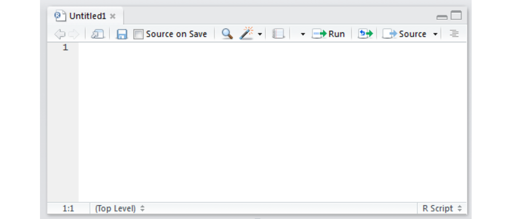

In contrast, code typed into the script editor pane does not automatically execute. The script editor provides a way to save the essential code for your analysis or project so it can be re-used or referred to for replication in the future. The editor also allows us to save, search, replace, etc. within an R ‘script.’ This is much like the difference between using a Stata .do file and the main Stata window!

R Studio provides a few convenient ways to send code from the script editor to be executed in the console pane.

- The **Run** button at the top right of the script editor pane provides several options.
- One of the most useful is the **CTRL+Enter** (PC) or **CMD+Enter** (Mac) shortcut to execute whichever lines are currenly selected in the script editor
  - If no complete lines are selected, this will execute the line where the cursor is placed.

### Other Panes

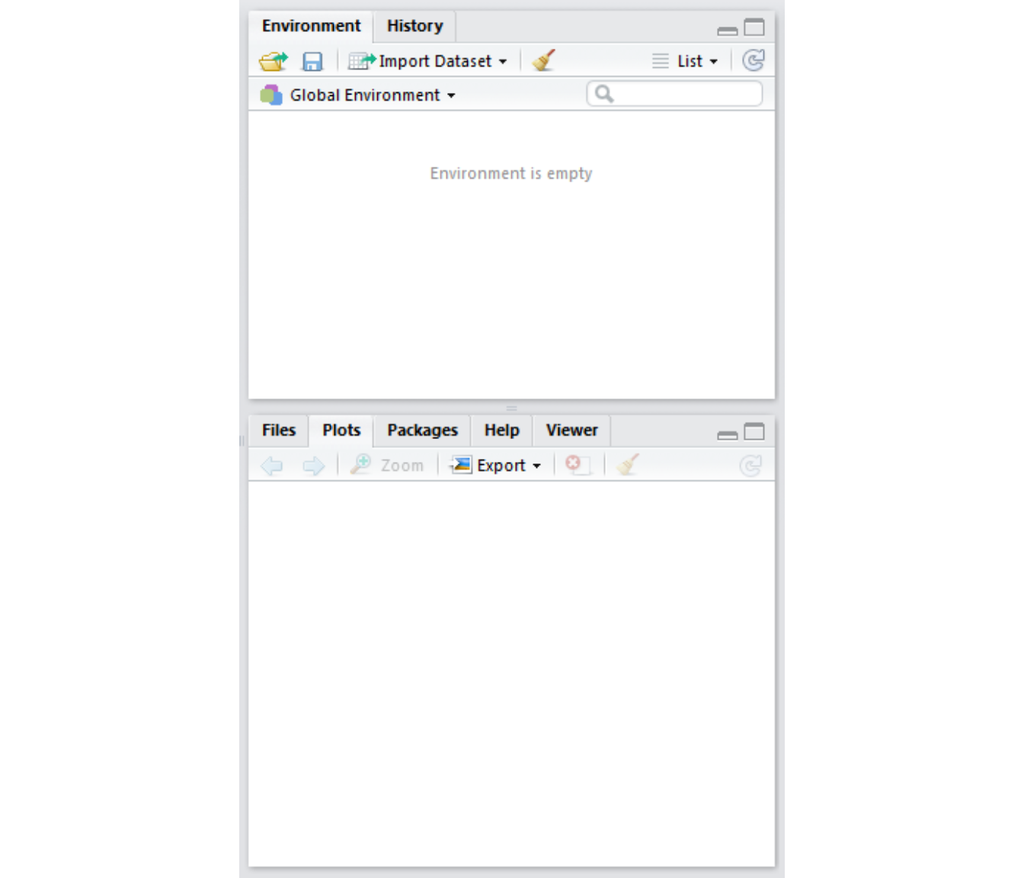

The other panes provided in R Studio are provided to make some coding tasks easier. Some users hide these windows as they are less essential to writing code. Some of the most useful panes are:

- **Environment** (top): Lists all objects and datasets defined in your current R session.
- **Plots** (bottom): Displays plots generated by R code.
- **Help** (bottom): Displays html format help files for R packages and functions
- **Files** (bottom): Lists files in the current working directory (more on this later!)

## Loading the tidyverse

```r
#install.packages("tidyverse")
library(tidyverse)
```

You only have to install a package once, but you’ll need to load it each time you start a new R session.

## A quick R example

For simplicity, today we’ll be working with datasets that are included with Base R.

```r
data()
```

From the Packages pane, we can click on the datasets package, which will take us to the help page:

[figure not shown]

Now we can read up on the available datasets.

Let’s start exploring the New York Air Quality dataset

```r
data(airquality)
head(airquality)
```

```
##   Ozone Solar.R Wind Temp Month Day
## 1    41     190  7.4   67     5   1
## 2    36     118  8.0   72     5   2
## 3    12     149 12.6   74     5   3
## 4    18     313 11.5   62     5   4
## 5    NA      NA 14.3   56     5   5
## 6    28      NA 14.9   66     5   6
```

```r
tail(airquality)
```

```
##     Ozone Solar.R Wind Temp Month Day
## 148    14      20 16.6   63     9  25
## 149    30     193  6.9   70     9  26
## 150    NA     145 13.2   77     9  27
## 151    14     191 14.3   75     9  28
## 152    18     131  8.0   76     9  29
## 153    20     223 11.5   68     9  30
```

```r
summary(airquality)
```

```
##      Ozone           Solar.R           Wind             Temp
##  Min.   :  1.00   Min.   :  7.0   Min.   : 1.700   Min.   :56.00
##  1st Qu.: 18.00   1st Qu.:115.8   1st Qu.: 7.400   1st Qu.:72.00
##  Median : 31.50   Median :205.0   Median : 9.700   Median :79.00
##  Mean   : 42.13   Mean   :185.9   Mean   : 9.958   Mean   :77.88
##  3rd Qu.: 63.25   3rd Qu.:258.8   3rd Qu.:11.500   3rd Qu.:85.00
##  Max.   :168.00   Max.   :334.0   Max.   :20.700   Max.   :97.00
##  NA's   :37       NA's   :7
##      Month            Day
##  Min.   :5.000   Min.   : 1.0
##  1st Qu.:6.000   1st Qu.: 8.0
##  Median :7.000   Median :16.0
##  Mean   :6.993   Mean   :15.8
##  3rd Qu.:8.000   3rd Qu.:23.0
##  Max.   :9.000   Max.   :31.0
##
```

## Interlude: What is airquality? data()? head()? summary()?

Unlike other popular statistical software, R is an object oriented programming language, similar to other popular languages such as Java, Python, Ruby, or C++.

airquality is an **object**. data(), head(), and summary() are **functions**. We’ll learn more about these as we go along, but for now, think of objects as nouns and functions as verbs.

## Plotting with ggplot2

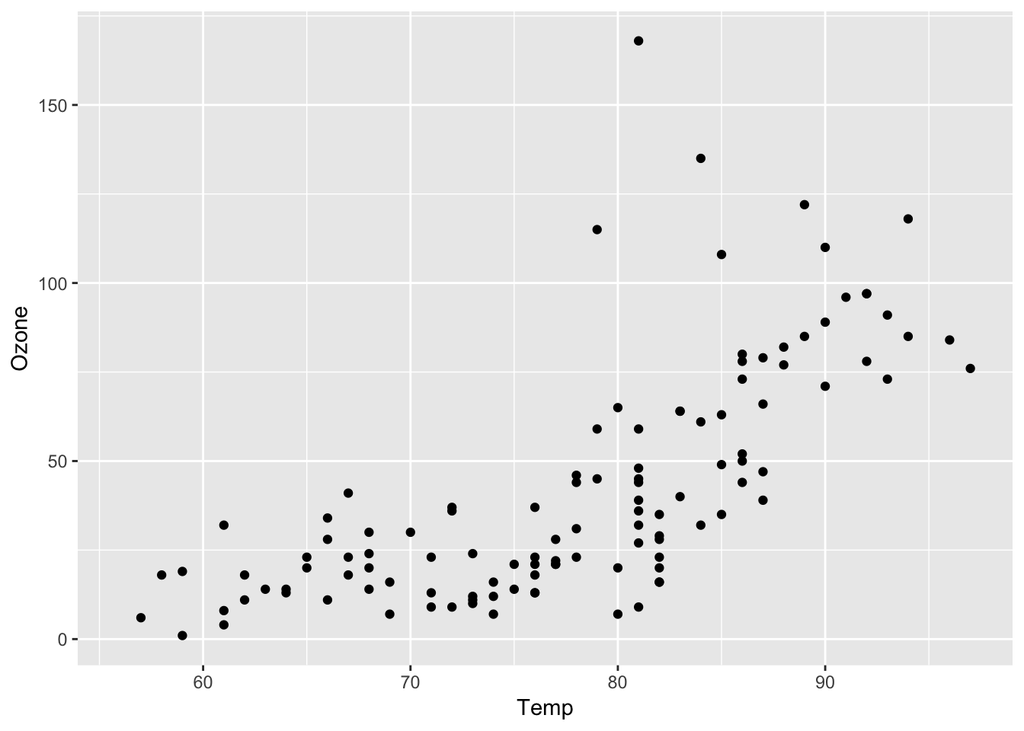

```r
ggplot(airquality, aes(x = Temp, y = Ozone)) +
  geom_point()
```

ggplot has a modular structure, so it’s easy to modify plots. Let’s add a best fit linear regression line.

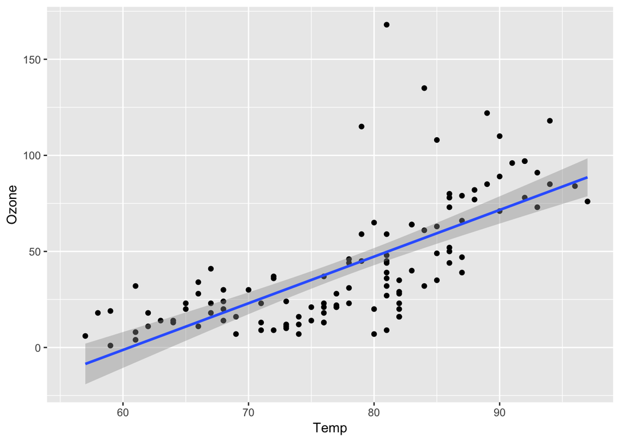

```r
ggplot(airquality, aes(x = Temp, y = Ozone)) +
  geom_point() + geom_smooth(method="lm")
```

Let’s change that to a loess (a locally-weighted version of linear regression).

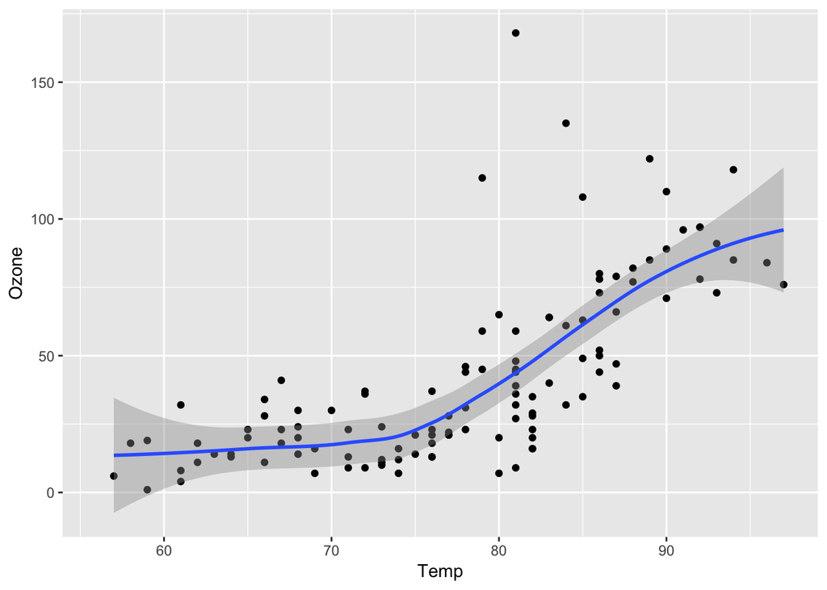

```r
ggplot(airquality, aes(x = Temp, y = Ozone)) +
  geom_point() + geom_smooth(method="loess")
```

What if we want to plot the data over time? We’ll have to do a little work.

## Creating a date variable

I don’t remember how to create dates in R, so let’s do a little searching.

Yes, I’m live googling in a class. [The pros do it all the time](https://medium.com/make-better-software/against-the-whiteboard-f1df0013954f). You should too.

This [stackoverflow.com page](https://stackoverflow.com/questions/26334763/merge-three-different-columns-into-a-date-in-r) suggests a solution.

First, we’ll create a new column in the airquality dataframe for the year.

```r
airquality$Year <- "1973"
```

There’s a lot going on in that one line of code.

- We are using the $ operator. This is a way to access individual columns of a dataframe.
- We are dealing with a brand new data type, character. This is indicated by the quotation marks around 1973.
- We are using the assignment operator <-, which can be read as “assign the character value 1973 to the Year column of the airquality dataframe.”

Now we can use the code snippet we found on stackoverflow.

```r
airquality$Date <- as.Date(with(airquality, paste(Year, Month, Day, sep="-"), "%Y-%m-%d"))
```

Let’s figure out why this works using R’s help system.

```r
?as.Date
#equivalent to help("as.Date")
#also try ??date
```

So as.Date() is a function that can take a character representation of a date and convert it into a Date object (or vice versa).

```r
?with
```

with() is a function that allows us to reference elements of data frame without having to type the data frame’s name repeatedly. This suggests we could get the same results as above with:

```r
airquality$Date2 <- as.Date(paste(airquality$Year, airquality$Month, airquality$Day, sep="-"), "%Y-%m-%d")
```

We can check the dataframe viewer to see that the results are indentical or we can use the all.equal() function.

```r
?paste
```

paste() lets us stick a bunch of character values together.

Finally, we can create a plot.

```r
ggplot(airquality, aes(x=Date, y=ozone)) +
  geom_point() + geom_smooth(method="loess") + theme_bw()
```

```
## Error in FUN(X[[i]], ...): object 'ozone' not found
```

Oops. Let’s try that again.

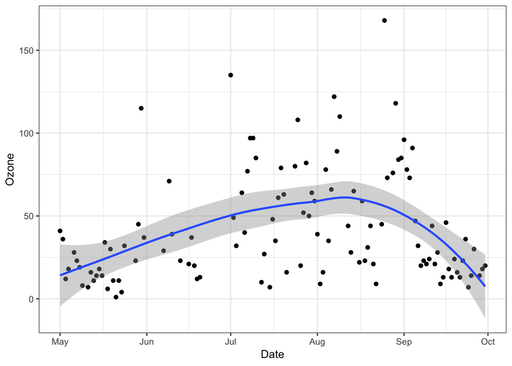

```r
ggplot(airquality, aes(x=Date, y=Ozone)) +
  geom_point() + geom_smooth(method="loess") + theme_bw()
```

## Other geoms: geom_boxplot() and geom_jitter()

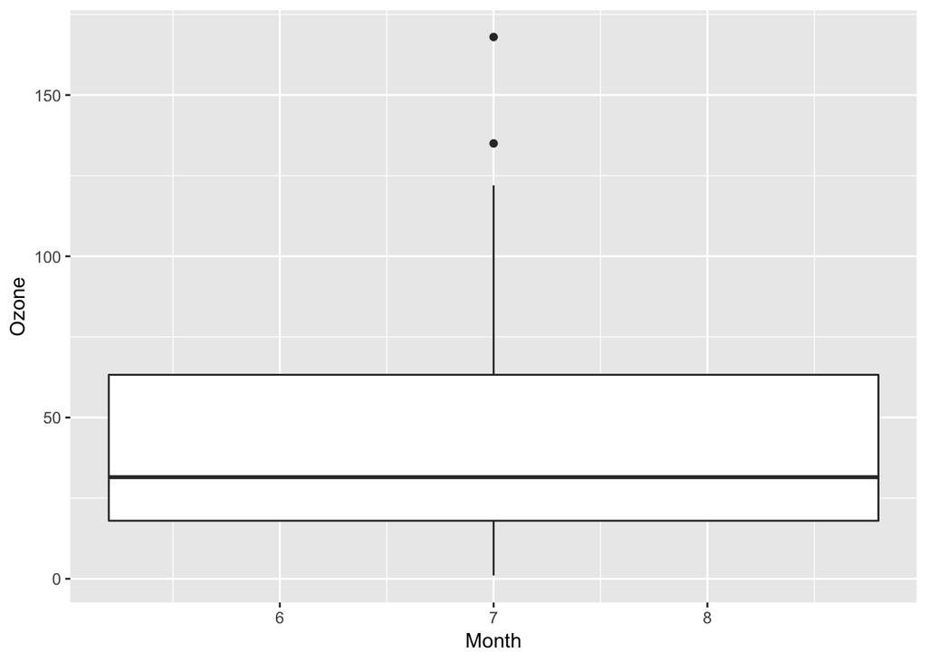

```r
ggplot(airquality, aes(x = Month, y = Ozone)) +
        geom_boxplot()
```

Looks like I left out something geom_boxplot() needs. Time for google!

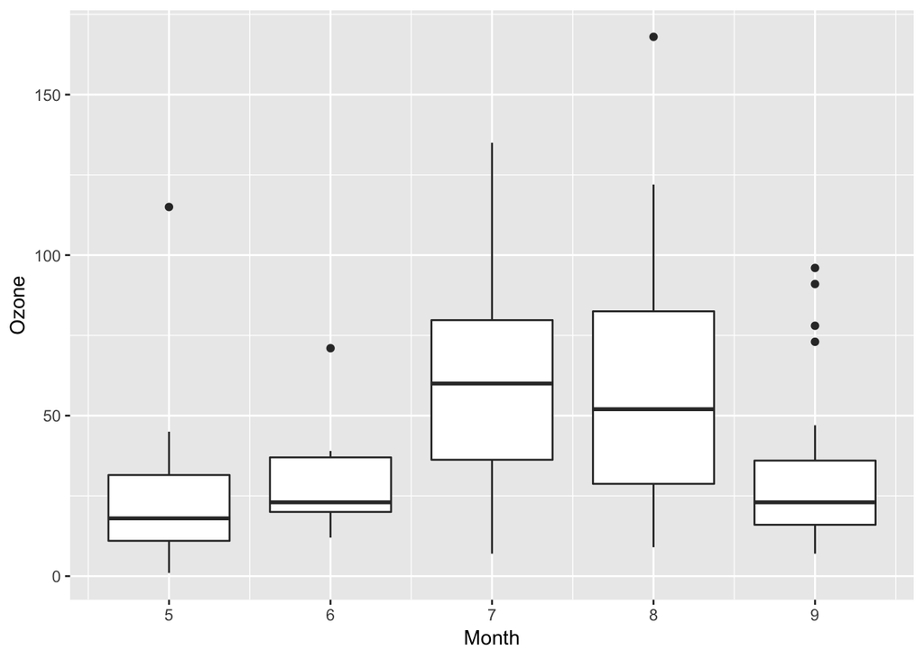

```r
ggplot(airquality, aes(x = Month, y = Ozone, group=Month)) +
        geom_boxplot()
```

Let’s fix up the x-axis labels.

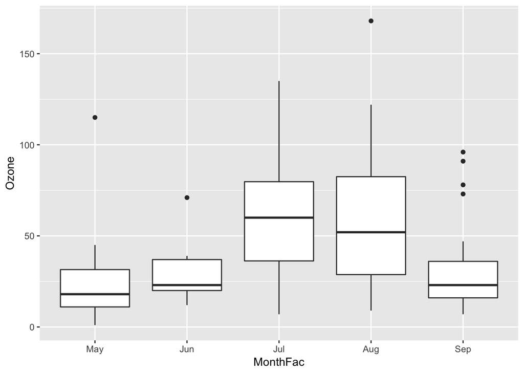

```r
airquality$MonthFac <- factor(airquality$Month,labels = c("May", "Jun", "Jul", "Aug", "Sep"))
ggplot(airquality, aes(x = MonthFac, y = Ozone)) +
        geom_boxplot()
```

Getting there, let’s try a few more tweaks.

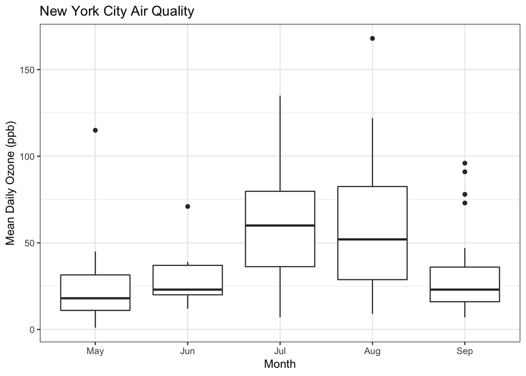

```r
ggplot(airquality, aes(x = MonthFac, y = Ozone)) +
        geom_boxplot() + xlab("Month") + ylab("Mean Daily Ozone (ppb)") + ggtitle("New York City Air Quality")  + theme_bw()
```

What if I want to see the original data and the boxplots?

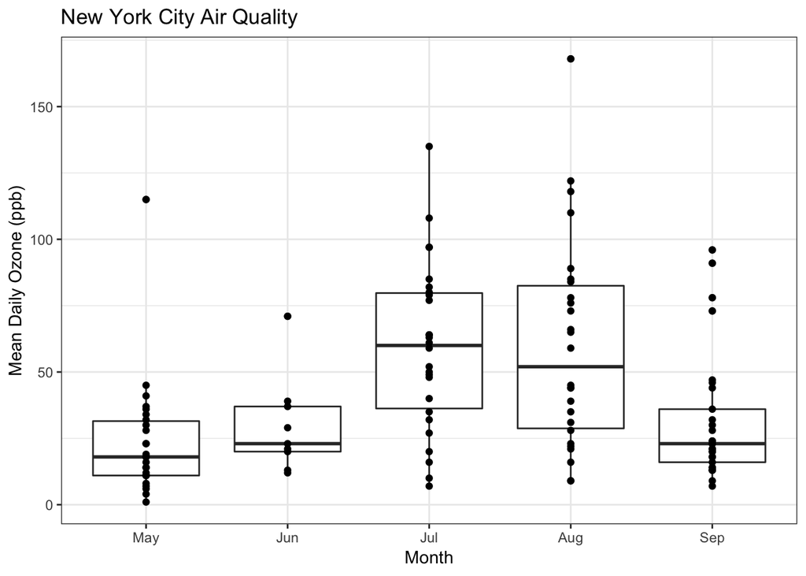

```r
ggplot(airquality, aes(x = MonthFac, y = Ozone)) +
        geom_boxplot() + xlab("Month") + ylab("Mean Daily Ozone (ppb)") + ggtitle("New York City Air Quality")  + theme_bw() + geom_point()
```

That’s hard to read, so let’s try using geom_jitter()

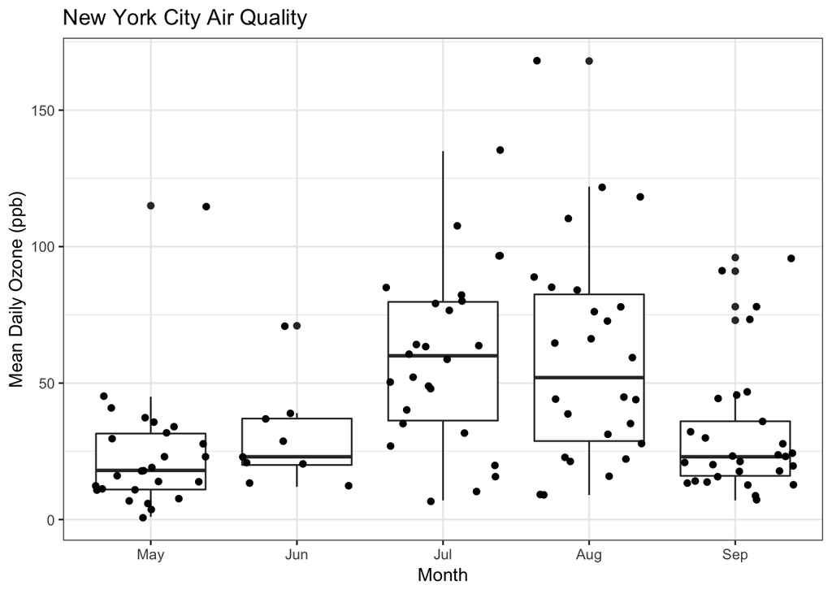

```r
ggplot(airquality, aes(x = MonthFac, y = Ozone)) +
        geom_boxplot() + xlab("Month") + ylab("Mean Daily Ozone (ppb)") + ggtitle("New York City Air Quality")  + theme_bw() + geom_jitter()
```

Maybe I can make the jittering a bit more compact. Time for the R help system, which we can access through the RStudio Help pane.

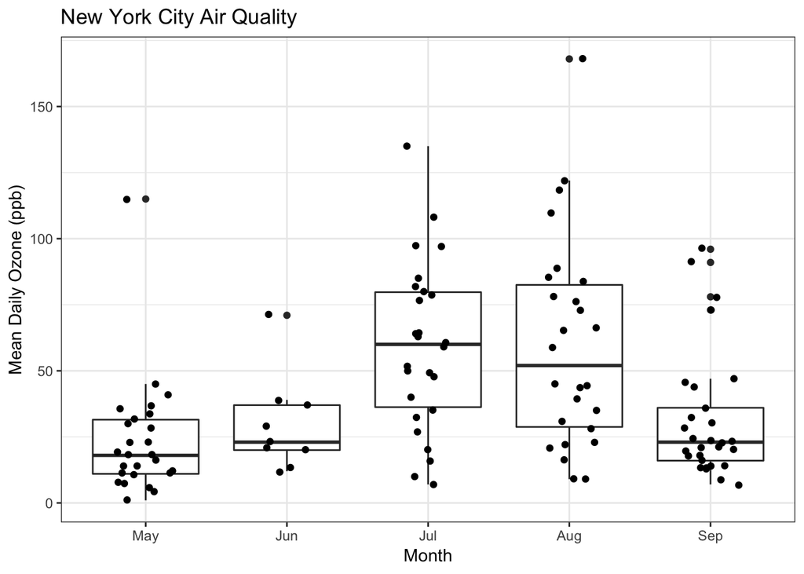

```r
ggplot(airquality, aes(x = MonthFac, y = Ozone)) +
        geom_boxplot() + xlab("Month") + ylab("Mean Daily Ozone (ppb)") + ggtitle("New York City Air Quality")  + theme_bw() + geom_jitter(width=0.2)
```

## Facets

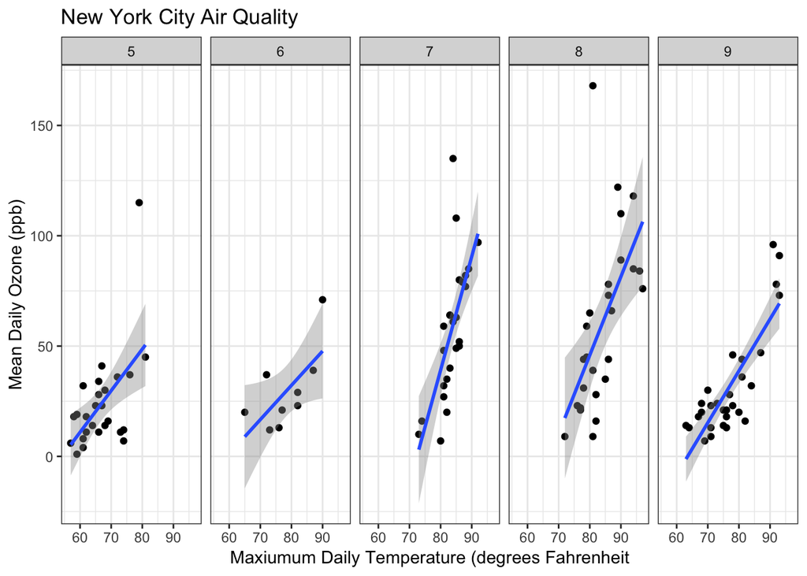

```r
ggplot(airquality, aes(x=Temp, y=Ozone)) + geom_point() + geom_smooth(method = "lm") + facet_grid(. ~ Month) + xlab("Maxiumum Daily Temperature (degrees Fahrenheit") + ylab("Mean Daily Ozone (ppb)") + ggtitle("New York City Air Quality") + theme_bw()
```

## Other Resources

**Quick References**

[Tidyverse Cheatsheets](https://www.rstudio.com/resources/cheatsheets/)

[Quick-R for Base R](https://www.statmethods.net/)

**Useful R Packages:**

[CRAN Task Views](https://cran.r-project.org/web/views/)

[Quick list of useful packages](https://support.rstudio.com/hc/en-us/articles/201057987-Quick-list-of-useful-R-packages)

**Advanced R Books:**

[ggplot2](http://had.co.nz/ggplot2/)

[Advanced R](http://adv-r.had.co.nz/)

[R packages](http://r-pkgs.had.co.nz/)

[Efficient R](https://csgillespie.github.io/efficientR/)

**Statistical Modeling Textbooks:**

[An Introduction to Statistical Learning](http://www-bcf.usc.edu/~gareth/ISL/)

[Regression Modeling Strategies](https://www.springer.com/us/book/9783319194240)

[Statistical Rethinking](https://xcelab.net/rm/statistical-rethinking/)

**Misc:**

https://github.com/ujjwalkarn/DataScienceR

## Feedback

[Let us know what you think of this lesson!](https://unc.az1.qualtrics.com/jfe/form/SV_8e1zRY2rlFUYBMx)